# Risk Factor Analysis

## Outcome Variable

**Outcome Variable:** whz

## Predictor Variables

**Intervention Variable:** mage

**Adjustment Set:**

- arm
- meducyrs
- feducyrs
- W_mhtcm
- W_mwtkg
- W_mbmi
- single
- delta_meducyrs
- delta_feducyrs
- delta_W_mhtcm
- delta_W_mwtkg
- delta_W_mbmi
- delta_single

## Stratifying Variables

The analysis was stratified on these variable(s):

- agecat
- studyid
- country

## Data Summary

| agecat | studyid | country | mage | n_cell | n |
| --- | --- | --- | --- | --- | --- |
| Birth | ki0047075b-MAL-ED | BANGLADESH | [20-30) | 148 | 215 |
| Birth | ki0047075b-MAL-ED | BANGLADESH | <20 | 28 | 215 |
| Birth | ki0047075b-MAL-ED | BANGLADESH | >=30 | 39 | 215 |
| Birth | ki0047075b-MAL-ED | BRAZIL | [20-30) | 39 | 62 |
| Birth | ki0047075b-MAL-ED | BRAZIL | <20 | 8 | 62 |
| Birth | ki0047075b-MAL-ED | BRAZIL | >=30 | 15 | 62 |
| Birth | ki0047075b-MAL-ED | INDIA | [20-30) | 36 | 45 |
| Birth | ki0047075b-MAL-ED | INDIA | <20 | 7 | 45 |
| Birth | ki0047075b-MAL-ED | INDIA | >=30 | 2 | 45 |
| Birth | ki0047075b-MAL-ED | NEPAL | [20-30) | 21 | 26 |
| Birth | ki0047075b-MAL-ED | NEPAL | <20 | 0 | 26 |
| Birth | ki0047075b-MAL-ED | NEPAL | >=30 | 5 | 26 |
| Birth | ki0047075b-MAL-ED | PERU | [20-30) | 113 | 228 |
| Birth | ki0047075b-MAL-ED | PERU | <20 | 63 | 228 |
| Birth | ki0047075b-MAL-ED | PERU | >=30 | 52 | 228 |
| Birth | ki0047075b-MAL-ED | SOUTH AFRICA | [20-30) | 65 | 120 |
| Birth | ki0047075b-MAL-ED | SOUTH AFRICA | <20 | 22 | 120 |
| Birth | ki0047075b-MAL-ED | SOUTH AFRICA | >=30 | 33 | 120 |
| Birth | ki0047075b-MAL-ED | TANZANIA, UNITED REPUBLIC OF | [20-30) | 66 | 115 |
| Birth | ki0047075b-MAL-ED | TANZANIA, UNITED REPUBLIC OF | <20 | 7 | 115 |
| Birth | ki0047075b-MAL-ED | TANZANIA, UNITED REPUBLIC OF | >=30 | 42 | 115 |
| Birth | ki1000108-CMC-V-BCS-2002 | INDIA | [20-30) | 75 | 86 |
| Birth | ki1000108-CMC-V-BCS-2002 | INDIA | <20 | 7 | 86 |
| Birth | ki1000108-CMC-V-BCS-2002 | INDIA | >=30 | 4 | 86 |
| Birth | ki1000108-IRC | INDIA | [20-30) | 289 | 343 |
| Birth | ki1000108-IRC | INDIA | <20 | 28 | 343 |
| Birth | ki1000108-IRC | INDIA | >=30 | 26 | 343 |
| Birth | ki1000109-EE | PAKISTAN | [20-30) | 68 | 177 |
| Birth | ki1000109-EE | PAKISTAN | <20 | 1 | 177 |
| Birth | ki1000109-EE | PAKISTAN | >=30 | 108 | 177 |

[output cut: 183 more lines]

The following strata were considered:

- agecat: 24 months, studyid: ki0047075b-MAL-ED, country: BANGLADESH
- agecat: 24 months, studyid: ki0047075b-MAL-ED, country: BRAZIL
- agecat: 24 months, studyid: ki0047075b-MAL-ED, country: INDIA
- agecat: 24 months, studyid: ki0047075b-MAL-ED, country: NEPAL
- agecat: 24 months, studyid: ki0047075b-MAL-ED, country: PERU
- agecat: 24 months, studyid: ki0047075b-MAL-ED, country: SOUTH AFRICA
- agecat: 24 months, studyid: ki0047075b-MAL-ED, country: TANZANIA, UNITED REPUBLIC OF
- agecat: 24 months, studyid: ki1000108-CMC-V-BCS-2002, country: INDIA
- agecat: 24 months, studyid: ki1000108-IRC, country: INDIA
- agecat: 24 months, studyid: ki1000109-EE, country: PAKISTAN
- agecat: 24 months, studyid: ki1017093-NIH-Birth, country: BANGLADESH
- agecat: 24 months, studyid: ki1017093b-PROVIDE, country: BANGLADESH
- agecat: 24 months, studyid: ki1017093c-NIH-Crypto, country: BANGLADESH
- agecat: 24 months, studyid: ki1066203-TanzaniaChild2, country: TANZANIA, UNITED REPUBLIC OF
- agecat: 24 months, studyid: ki1101329-Keneba, country: GAMBIA
- agecat: 24 months, studyid: ki1113344-GMS-Nepal, country: NEPAL
- agecat: 24 months, studyid: ki1119695-PROBIT, country: BELARUS
- agecat: 24 months, studyid: ki1126311-ZVITAMBO, country: ZIMBABWE
- agecat: 24 months, studyid: ki1135781-COHORTS, country: GUATEMALA
- agecat: 24 months, studyid: ki1135781-COHORTS, country: INDIA
- agecat: 24 months, studyid: ki1135781-COHORTS, country: PHILIPPINES
- agecat: 24 months, studyid: ki1148112-LCNI-5, country: MALAWI
- agecat: 24 months, studyid: kiGH5241-JiVitA-3, country: BANGLADESH
- agecat: 6 months, studyid: ki0047075b-MAL-ED, country: BANGLADESH
- agecat: 6 months, studyid: ki0047075b-MAL-ED, country: BRAZIL
- agecat: 6 months, studyid: ki0047075b-MAL-ED, country: INDIA
- agecat: 6 months, studyid: ki0047075b-MAL-ED, country: NEPAL
- agecat: 6 months, studyid: ki0047075b-MAL-ED, country: PERU
- agecat: 6 months, studyid: ki0047075b-MAL-ED, country: SOUTH AFRICA
- agecat: 6 months, studyid: ki0047075b-MAL-ED, country: TANZANIA, UNITED REPUBLIC OF
- agecat: 6 months, studyid: ki1000108-CMC-V-BCS-2002, country: INDIA
- agecat: 6 months, studyid: ki1000108-IRC, country: INDIA
- agecat: 6 months, studyid: ki1000109-EE, country: PAKISTAN
- agecat: 6 months, studyid: ki1000304b-SAS-CompFeed, country: INDIA
- agecat: 6 months, studyid: ki1000304b-SAS-FoodSuppl, country: INDIA
- agecat: 6 months, studyid: ki1017093-NIH-Birth, country: BANGLADESH
- agecat: 6 months, studyid: ki1017093b-PROVIDE, country: BANGLADESH
- agecat: 6 months, studyid: ki1017093c-NIH-Crypto, country: BANGLADESH
- agecat: 6 months, studyid: ki1066203-TanzaniaChild2, country: TANZANIA, UNITED REPUBLIC OF
- agecat: 6 months, studyid: ki1101329-Keneba, country: GAMBIA
- agecat: 6 months, studyid: ki1112895-Guatemala BSC, country: GUATEMALA
- agecat: 6 months, studyid: ki1113344-GMS-Nepal, country: NEPAL
- agecat: 6 months, studyid: ki1119695-PROBIT, country: BELARUS
- agecat: 6 months, studyid: ki1126311-ZVITAMBO, country: ZIMBABWE
- agecat: 6 months, studyid: ki1135781-COHORTS, country: GUATEMALA
- agecat: 6 months, studyid: ki1135781-COHORTS, country: INDIA
- agecat: 6 months, studyid: ki1135781-COHORTS, country: PHILIPPINES
- agecat: 6 months, studyid: ki1148112-LCNI-5, country: MALAWI
- agecat: 6 months, studyid: kiGH5241-JiVitA-3, country: BANGLADESH
- agecat: Birth, studyid: ki0047075b-MAL-ED, country: BANGLADESH
- agecat: Birth, studyid: ki0047075b-MAL-ED, country: BRAZIL
- agecat: Birth, studyid: ki0047075b-MAL-ED, country: INDIA
- agecat: Birth, studyid: ki0047075b-MAL-ED, country: NEPAL
- agecat: Birth, studyid: ki0047075b-MAL-ED, country: PERU
- agecat: Birth, studyid: ki0047075b-MAL-ED, country: SOUTH AFRICA
- agecat: Birth, studyid: ki0047075b-MAL-ED, country: TANZANIA, UNITED REPUBLIC OF
- agecat: Birth, studyid: ki1000108-CMC-V-BCS-2002, country: INDIA
- agecat: Birth, studyid: ki1000108-IRC, country: INDIA
- agecat: Birth, studyid: ki1000109-EE, country: PAKISTAN
- agecat: Birth, studyid: ki1000304b-SAS-CompFeed, country: INDIA
- agecat: Birth, studyid: ki1017093-NIH-Birth, country: BANGLADESH
- agecat: Birth, studyid: ki1017093b-PROVIDE, country: BANGLADESH
- agecat: Birth, studyid: ki1017093c-NIH-Crypto, country: BANGLADESH
- agecat: Birth, studyid: ki1101329-Keneba, country: GAMBIA
- agecat: Birth, studyid: ki1113344-GMS-Nepal, country: NEPAL
- agecat: Birth, studyid: ki1119695-PROBIT, country: BELARUS
- agecat: Birth, studyid: ki1126311-ZVITAMBO, country: ZIMBABWE
- agecat: Birth, studyid: ki1135781-COHORTS, country: GUATEMALA
- agecat: Birth, studyid: ki1135781-COHORTS, country: INDIA
- agecat: Birth, studyid: ki1135781-COHORTS, country: PHILIPPINES
- agecat: Birth, studyid: kiGH5241-JiVitA-3, country: BANGLADESH

### Dropped Strata

Some strata were dropped due to rare outcomes:

- agecat: Birth, studyid: ki0047075b-MAL-ED, country: INDIA
- agecat: Birth, studyid: ki0047075b-MAL-ED, country: NEPAL
- agecat: Birth, studyid: ki1000108-CMC-V-BCS-2002, country: INDIA
- agecat: Birth, studyid: ki1000109-EE, country: PAKISTAN
- agecat: Birth, studyid: ki1101329-Keneba, country: GAMBIA
- agecat: 6 months, studyid: ki1000109-EE, country: PAKISTAN
- agecat: 24 months, studyid: ki0047075b-MAL-ED, country: NEPAL
- agecat: 24 months, studyid: ki1000109-EE, country: PAKISTAN
- agecat: 24 months, studyid: ki1066203-TanzaniaChild2, country: TANZANIA, UNITED REPUBLIC OF

## Methods Detail

We’re interested in the causal parameters $E[Y_a]$ for all values of $a \in \mathcal{A}$. These parameters represent the mean outcome if, possibly contrary to fact, we intervened to set all units to have $A=a$. Under the randomization and positivity assumptions, these are identified by the statistical parameters $\psi_a=E_W[E_{Y|A,W}(Y|A=a,W)]$. In addition, we’re interested in the mean of $Y$, $E[Y]$ under no intervention (the observed mean). We will estimate these parameters by using SuperLearner to fit the relevant likelihood factors – $E_{Y|A,W}(Y|A=a,W)$ and $p(A=a|W)$, and then updating our likelihood fit using a joint TMLE.

For unadjusted analyses ($W=\{\}$), initial likelihoods were estimated using Lrnr_glm to estimate the simple $E(Y|A)$ and Lrnr_mean to estimate $p(A)$. For adjusted analyses, a small library containing Lrnr_glmnet, Lrnr_xgboost, and Lrnr_mean was used.

Having estimated these parameters, we will then use the delta method to estimate relative risks and attributable risks relative to a prespecified baseline level of $A$.

# Results Detail

## Results Plots

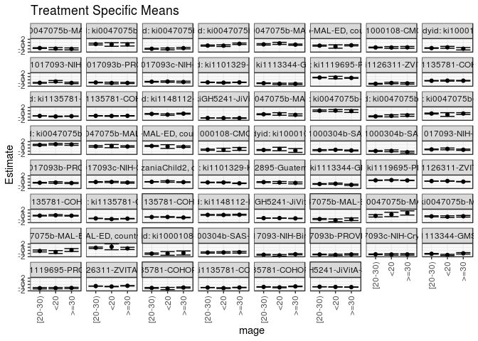

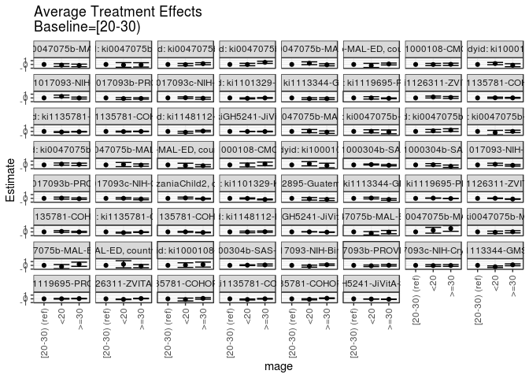

[figure not shown]

## Results Table

### Parameter: TSM

| agecat | studyid | country | intervention_level | baseline_level | estimate | ci_lower | ci_upper |
| --- | --- | --- | --- | --- | --- | --- | --- |
| Birth | ki0047075b-MAL-ED | BANGLADESH | [20-30) | NA | -0.8802927 | -1.0493533 | -0.7112321 |
| Birth | ki0047075b-MAL-ED | BANGLADESH | <20 | NA | -1.2606368 | -1.6735215 | -0.8477520 |
| Birth | ki0047075b-MAL-ED | BANGLADESH | >=30 | NA | -0.9385514 | -1.3435530 | -0.5335498 |
| Birth | ki0047075b-MAL-ED | BRAZIL | [20-30) | NA | 0.1282051 | -0.2476806 | 0.5040909 |
| Birth | ki0047075b-MAL-ED | BRAZIL | <20 | NA | 0.5562500 | -0.1284217 | 1.2409217 |
| Birth | ki0047075b-MAL-ED | BRAZIL | >=30 | NA | 1.0353333 | 0.3801713 | 1.6904954 |
| Birth | ki0047075b-MAL-ED | PERU | [20-30) | NA | -0.0206043 | -0.1799703 | 0.1387617 |
| Birth | ki0047075b-MAL-ED | PERU | <20 | NA | -0.1431625 | -0.4184654 | 0.1321405 |
| Birth | ki0047075b-MAL-ED | PERU | >=30 | NA | 0.0003536 | -0.2507130 | 0.2514202 |
| Birth | ki0047075b-MAL-ED | SOUTH AFRICA | [20-30) | NA | -0.1871084 | -0.4852453 | 0.1110286 |
| Birth | ki0047075b-MAL-ED | SOUTH AFRICA | <20 | NA | -0.5267160 | -0.9824097 | -0.0710224 |
| Birth | ki0047075b-MAL-ED | SOUTH AFRICA | >=30 | NA | 0.1086257 | -0.3501554 | 0.5674068 |
| Birth | ki0047075b-MAL-ED | TANZANIA, UNITED REPUBLIC OF | [20-30) | NA | 0.8186364 | 0.5971189 | 1.0401538 |
| Birth | ki0047075b-MAL-ED | TANZANIA, UNITED REPUBLIC OF | <20 | NA | 1.1171429 | 0.1947087 | 2.0395770 |
| Birth | ki0047075b-MAL-ED | TANZANIA, UNITED REPUBLIC OF | >=30 | NA | 0.6150000 | 0.2609657 | 0.9690343 |
| Birth | ki1000108-IRC | INDIA | [20-30) | NA | -1.0314533 | -1.2379730 | -0.8249335 |
| Birth | ki1000108-IRC | INDIA | <20 | NA | -0.9657143 | -1.5437779 | -0.3876507 |
| Birth | ki1000108-IRC | INDIA | >=30 | NA | -0.8269231 | -1.4629238 | -0.1909223 |
| Birth | ki1000304b-SAS-CompFeed | INDIA | [20-30) | NA | -0.6844988 | -0.8676376 | -0.5013600 |
| Birth | ki1000304b-SAS-CompFeed | INDIA | <20 | NA | -0.6443242 | -0.8591934 | -0.4294549 |
| Birth | ki1000304b-SAS-CompFeed | INDIA | >=30 | NA | -0.5782149 | -0.8416361 | -0.3147936 |
| Birth | ki1017093-NIH-Birth | BANGLADESH | [20-30) | NA | -1.3641974 | -1.4868856 | -1.2415091 |
| Birth | ki1017093-NIH-Birth | BANGLADESH | <20 | NA | -1.5775450 | -1.8209538 | -1.3341363 |
| Birth | ki1017093-NIH-Birth | BANGLADESH | >=30 | NA | -1.2064470 | -1.3878409 | -1.0250530 |
| Birth | ki1017093b-PROVIDE | BANGLADESH | [20-30) | NA | -1.2872352 | -1.3794672 | -1.1950032 |
| Birth | ki1017093b-PROVIDE | BANGLADESH | <20 | NA | -1.4056299 | -1.5999270 | -1.2113328 |
| Birth | ki1017093b-PROVIDE | BANGLADESH | >=30 | NA | -1.2695054 | -1.4653806 | -1.0736302 |
| Birth | ki1017093c-NIH-Crypto | BANGLADESH | [20-30) | NA | -1.2338234 | -1.3354304 | -1.1322163 |
| Birth | ki1017093c-NIH-Crypto | BANGLADESH | <20 | NA | -1.2882181 | -1.5038676 | -1.0725686 |
| Birth | ki1017093c-NIH-Crypto | BANGLADESH | >=30 | NA | -1.2667530 | -1.4837903 | -1.0497157 |

[output cut: 156 more lines]

### Parameter: E(Y)

| agecat | studyid | country | intervention_level | baseline_level | estimate | ci_lower | ci_upper |
| --- | --- | --- | --- | --- | --- | --- | --- |
| Birth | ki0047075b-MAL-ED | BANGLADESH | NA | NA | -0.9412093 | -1.0864308 | -0.7959878 |
| Birth | ki0047075b-MAL-ED | BRAZIL | NA | NA | 0.4029032 | 0.0896793 | 0.7161272 |
| Birth | ki0047075b-MAL-ED | PERU | NA | NA | -0.0520175 | -0.1725298 | 0.0684947 |
| Birth | ki0047075b-MAL-ED | SOUTH AFRICA | NA | NA | -0.1925833 | -0.4053570 | 0.0201904 |
| Birth | ki0047075b-MAL-ED | TANZANIA, UNITED REPUBLIC OF | NA | NA | 0.7624348 | 0.5710709 | 0.9537986 |
| Birth | ki1000108-IRC | INDIA | NA | NA | -1.0105831 | -1.1973019 | -0.8238643 |
| Birth | ki1000304b-SAS-CompFeed | INDIA | NA | NA | -0.6700453 | -0.8474950 | -0.4925957 |
| Birth | ki1017093-NIH-Birth | BANGLADESH | NA | NA | -1.3545637 | -1.4492090 | -1.2599184 |
| Birth | ki1017093b-PROVIDE | BANGLADESH | NA | NA | -1.2984586 | -1.3752758 | -1.2216415 |
| Birth | ki1017093c-NIH-Crypto | BANGLADESH | NA | NA | -1.2441513 | -1.3281130 | -1.1601897 |
| Birth | ki1113344-GMS-Nepal | NEPAL | NA | NA | -1.1164431 | -1.2040134 | -1.0288728 |
| Birth | ki1119695-PROBIT | BELARUS | NA | NA | -1.1448633 | -1.3544229 | -0.9353037 |
| Birth | ki1126311-ZVITAMBO | ZIMBABWE | NA | NA | -0.5144298 | -0.5403185 | -0.4885410 |
| Birth | ki1135781-COHORTS | GUATEMALA | NA | NA | -1.0621429 | -1.1631387 | -0.9611471 |
| Birth | ki1135781-COHORTS | INDIA | NA | NA | -0.9742815 | -1.0093427 | -0.9392203 |
| Birth | ki1135781-COHORTS | PHILIPPINES | NA | NA | -0.7427251 | -0.7890855 | -0.6963647 |
| Birth | kiGH5241-JiVitA-3 | BANGLADESH | NA | NA | -0.7500589 | -0.7679185 | -0.7321993 |
| 6 months | ki0047075b-MAL-ED | BANGLADESH | NA | NA | -0.1383956 | -0.2672708 | -0.0095204 |
| 6 months | ki0047075b-MAL-ED | BRAZIL | NA | NA | 0.9717225 | 0.8073791 | 1.1360658 |
| 6 months | ki0047075b-MAL-ED | INDIA | NA | NA | -0.7080627 | -0.8349927 | -0.5811326 |
| 6 months | ki0047075b-MAL-ED | NEPAL | NA | NA | 0.1110452 | -0.0202712 | 0.2423616 |
| 6 months | ki0047075b-MAL-ED | PERU | NA | NA | 1.0568987 | 0.9352990 | 1.1784983 |
| 6 months | ki0047075b-MAL-ED | SOUTH AFRICA | NA | NA | 0.5427231 | 0.3906363 | 0.6948099 |
| 6 months | ki0047075b-MAL-ED | TANZANIA, UNITED REPUBLIC OF | NA | NA | 0.5362213 | 0.4049390 | 0.6675036 |
| 6 months | ki1000108-CMC-V-BCS-2002 | INDIA | NA | NA | -0.5026766 | -0.6536848 | -0.3516685 |
| 6 months | ki1000108-IRC | INDIA | NA | NA | -0.5989297 | -0.7344491 | -0.4634104 |
| 6 months | ki1000304b-SAS-CompFeed | INDIA | NA | NA | -0.6657084 | -0.8024377 | -0.5289791 |
| 6 months | ki1000304b-SAS-FoodSuppl | INDIA | NA | NA | -1.0121579 | -1.1280429 | -0.8962729 |
| 6 months | ki1017093-NIH-Birth | BANGLADESH | NA | NA | -0.4495343 | -0.5402027 | -0.3588659 |
| 6 months | ki1017093b-PROVIDE | BANGLADESH | NA | NA | -0.1990907 | -0.2817968 | -0.1163845 |
| 6 months | ki1017093c-NIH-Crypto | BANGLADESH | NA | NA | 0.0297622 | -0.0491685 | 0.1086930 |
| 6 months | ki1066203-TanzaniaChild2 | TANZANIA, UNITED REPUBLIC OF | NA | NA | 0.0782666 | 0.0252568 | 0.1312764 |
| 6 months | ki1101329-Keneba | GAMBIA | NA | NA | -0.1833609 | -0.2343611 | -0.1323607 |
| 6 months | ki1112895-Guatemala BSC | GUATEMALA | NA | NA | -0.0619988 | -0.1773839 | 0.0533863 |
| 6 months | ki1113344-GMS-Nepal | NEPAL | NA | NA | -0.6038416 | -0.6899448 | -0.5177384 |
| 6 months | ki1119695-PROBIT | BELARUS | NA | NA | 0.5792439 | 0.5193388 | 0.6391490 |
| 6 months | ki1126311-ZVITAMBO | ZIMBABWE | NA | NA | 0.3103322 | 0.2846161 | 0.3360483 |
| 6 months | ki1135781-COHORTS | GUATEMALA | NA | NA | 0.1940810 | 0.1226351 | 0.2655269 |
| 6 months | ki1135781-COHORTS | INDIA | NA | NA | -0.7119298 | -0.7444861 | -0.6793734 |
| 6 months | ki1135781-COHORTS | PHILIPPINES | NA | NA | -0.2938433 | -0.3352064 | -0.2524802 |
| 6 months | ki1148112-LCNI-5 | MALAWI | NA | NA | 0.4409268 | 0.3613957 | 0.5204578 |
| 6 months | kiGH5241-JiVitA-3 | BANGLADESH | NA | NA | -0.5928614 | -0.6124287 | -0.5732940 |
| 24 months | ki0047075b-MAL-ED | BANGLADESH | NA | NA | -0.8201887 | -0.9423967 | -0.6979806 |
| 24 months | ki0047075b-MAL-ED | BRAZIL | NA | NA | 0.4592308 | 0.2528453 | 0.6656163 |
| 24 months | ki0047075b-MAL-ED | INDIA | NA | NA | -0.9571111 | -1.0731621 | -0.8410602 |
| 24 months | ki0047075b-MAL-ED | PERU | NA | NA | 0.1204478 | 0.0005049 | 0.2403906 |
| 24 months | ki0047075b-MAL-ED | SOUTH AFRICA | NA | NA | 0.4148529 | 0.2940577 | 0.5356481 |
| 24 months | ki0047075b-MAL-ED | TANZANIA, UNITED REPUBLIC OF | NA | NA | 0.0539486 | -0.0712465 | 0.1791437 |
| 24 months | ki1000108-CMC-V-BCS-2002 | INDIA | NA | NA | -0.5571505 | -0.6585247 | -0.4557763 |
| 24 months | ki1000108-IRC | INDIA | NA | NA | -0.7458150 | -0.8368180 | -0.6548120 |
| 24 months | ki1017093-NIH-Birth | BANGLADESH | NA | NA | -0.9097790 | -1.0080462 | -0.8115117 |
| 24 months | ki1017093b-PROVIDE | BANGLADESH | NA | NA | -0.8928670 | -0.9755153 | -0.8102187 |
| 24 months | ki1017093c-NIH-Crypto | BANGLADESH | NA | NA | -0.6103502 | -0.7050157 | -0.5156847 |
| 24 months | ki1101329-Keneba | GAMBIA | NA | NA | -0.8079199 | -0.8550714 | -0.7607684 |
| 24 months | ki1113344-GMS-Nepal | NEPAL | NA | NA | -1.1363107 | -1.2252817 | -1.0473398 |
| 24 months | ki1119695-PROBIT | BELARUS | NA | NA | 0.6874295 | 0.5756922 | 0.7991668 |
| 24 months | ki1126311-ZVITAMBO | ZIMBABWE | NA | NA | -1.1845602 | -1.2836321 | -1.0854883 |
| 24 months | ki1135781-COHORTS | GUATEMALA | NA | NA | -0.2813755 | -0.3354674 | -0.2272835 |
| 24 months | ki1135781-COHORTS | INDIA | NA | NA | -0.6627749 | -0.6962103 | -0.6293395 |
| 24 months | ki1135781-COHORTS | PHILIPPINES | NA | NA | -0.6099592 | -0.6467541 | -0.5731643 |
| 24 months | ki1148112-LCNI-5 | MALAWI | NA | NA | -0.0115944 | -0.1019822 | 0.0787935 |
| 24 months | kiGH5241-JiVitA-3 | BANGLADESH | NA | NA | -1.2993367 | -1.3226993 | -1.2759741 |

### Parameter: ATE

| agecat | studyid | country | intervention_level | baseline_level | estimate | ci_lower | ci_upper |
| --- | --- | --- | --- | --- | --- | --- | --- |
| Birth | ki0047075b-MAL-ED | BANGLADESH | [20-30) | [20-30) | 0.0000000 | 0.0000000 | 0.0000000 |
| Birth | ki0047075b-MAL-ED | BANGLADESH | <20 | [20-30) | -0.3803440 | -0.8270510 | 0.0663630 |
| Birth | ki0047075b-MAL-ED | BANGLADESH | >=30 | [20-30) | -0.0582587 | -0.4975634 | 0.3810460 |
| Birth | ki0047075b-MAL-ED | BRAZIL | [20-30) | [20-30) | 0.0000000 | 0.0000000 | 0.0000000 |
| Birth | ki0047075b-MAL-ED | BRAZIL | <20 | [20-30) | 0.4280449 | -0.3530220 | 1.2091117 |
| Birth | ki0047075b-MAL-ED | BRAZIL | >=30 | [20-30) | 0.9071282 | 0.1517955 | 1.6624609 |
| Birth | ki0047075b-MAL-ED | PERU | [20-30) | [20-30) | 0.0000000 | 0.0000000 | 0.0000000 |
| Birth | ki0047075b-MAL-ED | PERU | <20 | [20-30) | -0.1225582 | -0.4408634 | 0.1957471 |
| Birth | ki0047075b-MAL-ED | PERU | >=30 | [20-30) | 0.0209579 | -0.2766936 | 0.3186093 |
| Birth | ki0047075b-MAL-ED | SOUTH AFRICA | [20-30) | [20-30) | 0.0000000 | 0.0000000 | 0.0000000 |
| Birth | ki0047075b-MAL-ED | SOUTH AFRICA | <20 | [20-30) | -0.3396076 | -0.8907103 | 0.2114950 |
| Birth | ki0047075b-MAL-ED | SOUTH AFRICA | >=30 | [20-30) | 0.2957341 | -0.2641549 | 0.8556232 |
| Birth | ki0047075b-MAL-ED | TANZANIA, UNITED REPUBLIC OF | [20-30) | [20-30) | 0.0000000 | 0.0000000 | 0.0000000 |
| Birth | ki0047075b-MAL-ED | TANZANIA, UNITED REPUBLIC OF | <20 | [20-30) | 0.2985065 | -0.6501530 | 1.2471660 |
| Birth | ki0047075b-MAL-ED | TANZANIA, UNITED REPUBLIC OF | >=30 | [20-30) | -0.2036364 | -0.6212610 | 0.2139882 |
| Birth | ki1000108-IRC | INDIA | [20-30) | [20-30) | 0.0000000 | 0.0000000 | 0.0000000 |
| Birth | ki1000108-IRC | INDIA | <20 | [20-30) | 0.0657390 | -0.5481078 | 0.6795858 |
| Birth | ki1000108-IRC | INDIA | >=30 | [20-30) | 0.2045302 | -0.4641606 | 0.8732210 |
| Birth | ki1000304b-SAS-CompFeed | INDIA | [20-30) | [20-30) | 0.0000000 | 0.0000000 | 0.0000000 |
| Birth | ki1000304b-SAS-CompFeed | INDIA | <20 | [20-30) | 0.0401746 | -0.0680104 | 0.1483596 |
| Birth | ki1000304b-SAS-CompFeed | INDIA | >=30 | [20-30) | 0.1062839 | -0.1426887 | 0.3552566 |
| Birth | ki1017093-NIH-Birth | BANGLADESH | [20-30) | [20-30) | 0.0000000 | 0.0000000 | 0.0000000 |
| Birth | ki1017093-NIH-Birth | BANGLADESH | <20 | [20-30) | -0.2133477 | -0.4860332 | 0.0593378 |
| Birth | ki1017093-NIH-Birth | BANGLADESH | >=30 | [20-30) | 0.1577504 | -0.0623069 | 0.3778077 |
| Birth | ki1017093b-PROVIDE | BANGLADESH | [20-30) | [20-30) | 0.0000000 | 0.0000000 | 0.0000000 |
| Birth | ki1017093b-PROVIDE | BANGLADESH | <20 | [20-30) | -0.1183947 | -0.3329544 | 0.0961651 |
| Birth | ki1017093b-PROVIDE | BANGLADESH | >=30 | [20-30) | 0.0177298 | -0.1985887 | 0.2340483 |
| Birth | ki1017093c-NIH-Crypto | BANGLADESH | [20-30) | [20-30) | 0.0000000 | 0.0000000 | 0.0000000 |
| Birth | ki1017093c-NIH-Crypto | BANGLADESH | <20 | [20-30) | -0.0543948 | -0.2927019 | 0.1839124 |
| Birth | ki1017093c-NIH-Crypto | BANGLADESH | >=30 | [20-30) | -0.0329297 | -0.2717217 | 0.2058623 |

[output cut: 156 more lines]

### Parameter: PAR

| agecat | studyid | country | intervention_level | baseline_level | estimate | ci_lower | ci_upper |
| --- | --- | --- | --- | --- | --- | --- | --- |
| Birth | ki0047075b-MAL-ED | BANGLADESH | [20-30) | NA | -0.0609166 | -0.1636855 | 0.0418524 |
| Birth | ki0047075b-MAL-ED | BRAZIL | [20-30) | NA | 0.2746981 | 0.0264094 | 0.5229868 |
| Birth | ki0047075b-MAL-ED | PERU | [20-30) | NA | -0.0314132 | -0.1542218 | 0.0913954 |
| Birth | ki0047075b-MAL-ED | SOUTH AFRICA | [20-30) | NA | -0.0054749 | -0.2200929 | 0.2091430 |
| Birth | ki0047075b-MAL-ED | TANZANIA, UNITED REPUBLIC OF | [20-30) | NA | -0.0562016 | -0.2275676 | 0.1151644 |
| Birth | ki1000108-IRC | INDIA | [20-30) | NA | 0.0208702 | -0.0542483 | 0.0959887 |
| Birth | ki1000304b-SAS-CompFeed | INDIA | [20-30) | NA | 0.0144535 | -0.0217368 | 0.0506437 |
| Birth | ki1017093-NIH-Birth | BANGLADESH | [20-30) | NA | 0.0096337 | -0.0532121 | 0.0724795 |
| Birth | ki1017093b-PROVIDE | BANGLADESH | [20-30) | NA | -0.0112234 | -0.0630179 | 0.0405710 |
| Birth | ki1017093c-NIH-Crypto | BANGLADESH | [20-30) | NA | -0.0103280 | -0.0710706 | 0.0504147 |
| Birth | ki1113344-GMS-Nepal | NEPAL | [20-30) | NA | -0.0405822 | -0.1045822 | 0.0234178 |
| Birth | ki1119695-PROBIT | BELARUS | [20-30) | NA | 0.0131927 | -0.0038595 | 0.0302450 |
| Birth | ki1126311-ZVITAMBO | ZIMBABWE | [20-30) | NA | -0.0101318 | -0.0283912 | 0.0081275 |
| Birth | ki1135781-COHORTS | GUATEMALA | [20-30) | NA | 0.0247339 | -0.0847072 | 0.1341749 |
| Birth | ki1135781-COHORTS | INDIA | [20-30) | NA | -0.0116214 | -0.0367994 | 0.0135566 |
| Birth | ki1135781-COHORTS | PHILIPPINES | [20-30) | NA | 0.0230727 | -0.0148904 | 0.0610358 |
| Birth | kiGH5241-JiVitA-3 | BANGLADESH | [20-30) | NA | -0.0328624 | -0.0481309 | -0.0175940 |
| 6 months | ki0047075b-MAL-ED | BANGLADESH | [20-30) | NA | -0.0338734 | -0.1234165 | 0.0556697 |
| 6 months | ki0047075b-MAL-ED | BRAZIL | [20-30) | NA | -0.0374630 | -0.1849165 | 0.1099904 |
| 6 months | ki0047075b-MAL-ED | INDIA | [20-30) | NA | 0.0507450 | -0.0126184 | 0.1141085 |
| 6 months | ki0047075b-MAL-ED | NEPAL | [20-30) | NA | -0.0064323 | -0.0723020 | 0.0594375 |
| 6 months | ki0047075b-MAL-ED | PERU | [20-30) | NA | 0.0737383 | -0.0596478 | 0.2071243 |
| 6 months | ki0047075b-MAL-ED | SOUTH AFRICA | [20-30) | NA | 0.0286037 | -0.1388192 | 0.1960265 |
| 6 months | ki0047075b-MAL-ED | TANZANIA, UNITED REPUBLIC OF | [20-30) | NA | -0.1007622 | -0.2279895 | 0.0264651 |
| 6 months | ki1000108-CMC-V-BCS-2002 | INDIA | [20-30) | NA | 0.0276202 | -0.0496471 | 0.1048875 |
| 6 months | ki1000108-IRC | INDIA | [20-30) | NA | 0.0163578 | -0.0532078 | 0.0859233 |
| 6 months | ki1000304b-SAS-CompFeed | INDIA | [20-30) | NA | 0.0011526 | -0.0340298 | 0.0363350 |
| 6 months | ki1000304b-SAS-FoodSuppl | INDIA | [20-30) | NA | -0.0853408 | -0.1679659 | -0.0027158 |
| 6 months | ki1017093-NIH-Birth | BANGLADESH | [20-30) | NA | -0.0108935 | -0.0745628 | 0.0527758 |
| 6 months | ki1017093b-PROVIDE | BANGLADESH | [20-30) | NA | -0.0102713 | -0.0612714 | 0.0407288 |
| 6 months | ki1017093c-NIH-Crypto | BANGLADESH | [20-30) | NA | -0.0126143 | -0.0706153 | 0.0453866 |
| 6 months | ki1066203-TanzaniaChild2 | TANZANIA, UNITED REPUBLIC OF | [20-30) | NA | -0.0162389 | -0.0563841 | 0.0239063 |
| 6 months | ki1101329-Keneba | GAMBIA | [20-30) | NA | -0.0982004 | -0.1528754 | -0.0435253 |
| 6 months | ki1112895-Guatemala BSC | GUATEMALA | [20-30) | NA | -0.0704443 | -0.1641685 | 0.0232800 |
| 6 months | ki1113344-GMS-Nepal | NEPAL | [20-30) | NA | -0.0276392 | -0.0886277 | 0.0333493 |
| 6 months | ki1119695-PROBIT | BELARUS | [20-30) | NA | 0.0022281 | -0.0089004 | 0.0133566 |
| 6 months | ki1126311-ZVITAMBO | ZIMBABWE | [20-30) | NA | -0.0226633 | -0.0412632 | -0.0040634 |
| 6 months | ki1135781-COHORTS | GUATEMALA | [20-30) | NA | 0.0046673 | -0.0734551 | 0.0827897 |
| 6 months | ki1135781-COHORTS | INDIA | [20-30) | NA | -0.0351915 | -0.0577600 | -0.0126231 |
| 6 months | ki1135781-COHORTS | PHILIPPINES | [20-30) | NA | -0.0540703 | -0.0894272 | -0.0187134 |
| 6 months | ki1148112-LCNI-5 | MALAWI | [20-30) | NA | 0.0108095 | -0.0622203 | 0.0838393 |
| 6 months | kiGH5241-JiVitA-3 | BANGLADESH | [20-30) | NA | -0.0005555 | -0.0195095 | 0.0183985 |
| 24 months | ki0047075b-MAL-ED | BANGLADESH | [20-30) | NA | -0.0702384 | -0.1525793 | 0.0121025 |
| 24 months | ki0047075b-MAL-ED | BRAZIL | [20-30) | NA | -0.0486441 | -0.2330248 | 0.1357366 |
| 24 months | ki0047075b-MAL-ED | INDIA | [20-30) | NA | 0.0119950 | -0.0433112 | 0.0673013 |
| 24 months | ki0047075b-MAL-ED | PERU | [20-30) | NA | 0.0916200 | -0.0525405 | 0.2357805 |
| 24 months | ki0047075b-MAL-ED | SOUTH AFRICA | [20-30) | NA | 0.0013764 | -0.1460693 | 0.1488222 |
| 24 months | ki0047075b-MAL-ED | TANZANIA, UNITED REPUBLIC OF | [20-30) | NA | 0.0408513 | -0.0774331 | 0.1591356 |
| 24 months | ki1000108-CMC-V-BCS-2002 | INDIA | [20-30) | NA | 0.0017628 | -0.0449995 | 0.0485250 |
| 24 months | ki1000108-IRC | INDIA | [20-30) | NA | 0.0069158 | -0.0351308 | 0.0489624 |
| 24 months | ki1017093-NIH-Birth | BANGLADESH | [20-30) | NA | 0.0381450 | -0.0313188 | 0.1076087 |
| 24 months | ki1017093b-PROVIDE | BANGLADESH | [20-30) | NA | -0.0436628 | -0.0939707 | 0.0066450 |
| 24 months | ki1017093c-NIH-Crypto | BANGLADESH | [20-30) | NA | -0.0097174 | -0.0763340 | 0.0568991 |
| 24 months | ki1101329-Keneba | GAMBIA | [20-30) | NA | -0.0120329 | -0.0649089 | 0.0408430 |
| 24 months | ki1113344-GMS-Nepal | NEPAL | [20-30) | NA | -0.0666771 | -0.1322821 | -0.0010721 |
| 24 months | ki1119695-PROBIT | BELARUS | [20-30) | NA | -0.0145051 | -0.0592275 | 0.0302172 |
| 24 months | ki1126311-ZVITAMBO | ZIMBABWE | [20-30) | NA | 0.0603390 | -0.0145653 | 0.1352434 |
| 24 months | ki1135781-COHORTS | GUATEMALA | [20-30) | NA | 0.0207265 | -0.0351780 | 0.0766310 |
| 24 months | ki1135781-COHORTS | INDIA | [20-30) | NA | -0.0325748 | -0.0560297 | -0.0091200 |
| 24 months | ki1135781-COHORTS | PHILIPPINES | [20-30) | NA | -0.0131929 | -0.0436316 | 0.0172458 |
| 24 months | ki1148112-LCNI-5 | MALAWI | [20-30) | NA | -0.0055081 | -0.0907662 | 0.0797501 |
| 24 months | kiGH5241-JiVitA-3 | BANGLADESH | [20-30) | NA | -0.0122195 | -0.0357635 | 0.0113246 |